[figure not shown]

# 1.

Indlæsning af data

```r
afl2 <- read.table("../data/afl2.txt", header = T)
head(afl2)
```

```
  treat day logco2
1   raj   2   0.42
2   raj   2   0.37
3   raj   4   1.02
4   raj   4   1.27
5   raj   6   1.64
6   raj   6   1.46
```

Datasættet indeholder

- responsvariablen **logco2**
- behandlingsfaktoren **treat** med to niveauer: kontrol, raj
- variablen **dag** der angiver tidspunktet for analysen af prøven (kan indgå både som faktor og som kovariat)

Det er tanken, at **dag** indgår som faktor i analysen ved besvarelsen af delopgave 1.-3.

# 2.

Der er to gentagelser for hver kombination af faktorerne **treat** og **day**

```r
table(afl2$treat, afl2$day)
```

```
          2 4 6 7 9 12
  kontrol 2 2 2 2 2  2
  raj     2 2 2 2 2  2
```

Derfor er det muligt at lade analysen tage udgangspunkt i en model for 2-sidet variansanalyse med vekselvirkning.

# 3.

### Modelreduktion

Test for effekt af vekselvirkning (F = 1.2952, P = 0.3287)

```r
m0 <- lm(logco2 ~ factor(day) * treat, data = afl2)
m1 <- lm(logco2 ~ factor(day) + treat, data = afl2)
anova(m1, m0)
```

```
Analysis of Variance Table

Model 1: logco2 ~ factor(day) + treat
Model 2: logco2 ~ factor(day) * treat
  Res.Df     RSS Df Sum of Sq      F Pr(>F)
1     17 0.26713
2     12 0.17350  5  0.093633 1.2952 0.3287
```

Test for hovedeffekter (forkastes!)

```r
m2a <- lm(logco2 ~ treat, data = afl2)
m2b <- lm(logco2 ~ factor(day), data = afl2)
anova(m2a, m1)
```

```
Analysis of Variance Table

Model 1: logco2 ~ treat
Model 2: logco2 ~ factor(day) + treat
  Res.Df     RSS Df Sum of Sq      F    Pr(>F)
1     22 13.7347
2     17  0.2671  5    13.468 171.41 6.365e-14 ***
---
Signif. codes:  0 '***' 0.001 '**' 0.01 '*' 0.05 '.' 0.1 ' ' 1
```

```r
anova(m2b, m1)
```

```
Analysis of Variance Table

Model 1: logco2 ~ factor(day)
Model 2: logco2 ~ factor(day) + treat
  Res.Df     RSS Df Sum of Sq      F    Pr(>F)
1     18 14.4352
2     17  0.2671  1    14.168 901.64 3.598e-16 ***
---
Signif. codes:  0 '***' 0.001 '**' 0.01 '*' 0.05 '.' 0.1 ' ' 1
```

Konklusion: den additive model lader til at give en fornuftig beskrivelse af, hvordan CO2-indholdet afhænger af faktorerne **treat** og **day**.

### Parameterestimater

```r
summary(m1)
```

```
Call:
lm(formula = logco2 ~ factor(day) + treat, data = afl2)

Residuals:
      Min        1Q    Median        3Q       Max
-0.239167 -0.075833 -0.000417  0.076667  0.205833

Coefficients:
              Estimate Std. Error t value Pr(>|t|)
(Intercept)   -1.07583    0.06770  -15.89 1.23e-11 ***
factor(day)4   0.68250    0.08864    7.70 6.12e-07 ***
factor(day)6   1.07500    0.08864   12.13 8.55e-10 ***
factor(day)7   1.43500    0.08864   16.19 9.17e-12 ***
factor(day)9   1.80750    0.08864   20.39 2.18e-13 ***
factor(day)12  2.30500    0.08864   26.00 3.95e-15 ***
treatraj       1.53667    0.05118   30.03 3.60e-16 ***
---
Signif. codes:  0 '***' 0.001 '**' 0.01 '*' 0.05 '.' 0.1 ' ' 1

Residual standard error: 0.1254 on 17 degrees of freedom
Multiple R-squared:  0.9904,    Adjusted R-squared:  0.987
F-statistic: 293.1 on 6 and 17 DF,  p-value: 3.385e-16
```

Estimaterne kan omregnes til sædvanelig skala ved at transformere med den inverse funktion til logaritmen (dvs. tage eksponentialfunktionen).

### LSD-værdier

Der findes en pæn formel til beregning af LSD-værdier for en additive model for 2-sidet ANOVA i et balanceret forsøg.

LSD-værdien beregnes til

$$0.1254 * \sqrt{\tfrac{1}{4}+\tfrac{1}{4}} * 2.1098 = 0.1871$$

# 4.

Som i eksemplet fra kursusuge 3 med hydrolyse af fødevarer, så er det muligt at lave et formelt test af, om det er rimeligt at lave **day** indgå som en kovariat i modellen i stedet for som en faktor. Fortolkningsmæssigt svarer dette til at modellere sammenhængen mellem **day** og (logaritmen) til CO2 ved en lineær funktion.

Da vi i opgave 3 har reduceret den 2-sidede ANOVA til en additiv model, så skal linearitetshypotesen testes under den forudsætning, at linjerne er parellelle (dvs. samme hældning for de to niveauer af **treat**).

```r
m3 <- lm(logco2 ~ treat + day, data = afl2)
anova(m3, m1)
```

```
Analysis of Variance Table

Model 1: logco2 ~ treat + day
Model 2: logco2 ~ factor(day) + treat
  Res.Df     RSS Df Sum of Sq      F  Pr(>F)
1     21 0.54264
2     17 0.26713  4   0.27551 4.3833 0.01286 *
---
Signif. codes:  0 '***' 0.001 '**' 0.01 '*' 0.05 '.' 0.1 ' ' 1
```

P-værdien udtrykker, at det kan ikke virker helt rimeligt, at benytte en lineær funktion til at beskrive sammenhængen mellem **day** og **logco2**.

# 5.

### Kommentarer

En relevant figur kan fz. laves med følgende kode

```r
library(ggplot2)
ggplot(data = afl2) + geom_point(aes(x = day, y = logco2, col = treat)) +
  labs(x = "Days", y = "log(CO2)")
```

Figuren antyder, at sammenhængen mellem **day** og **logco2** ikke er lineær, men at der ses en svag tendens til at punkterne ligger på en kurve der krummer lidt.

### Figur

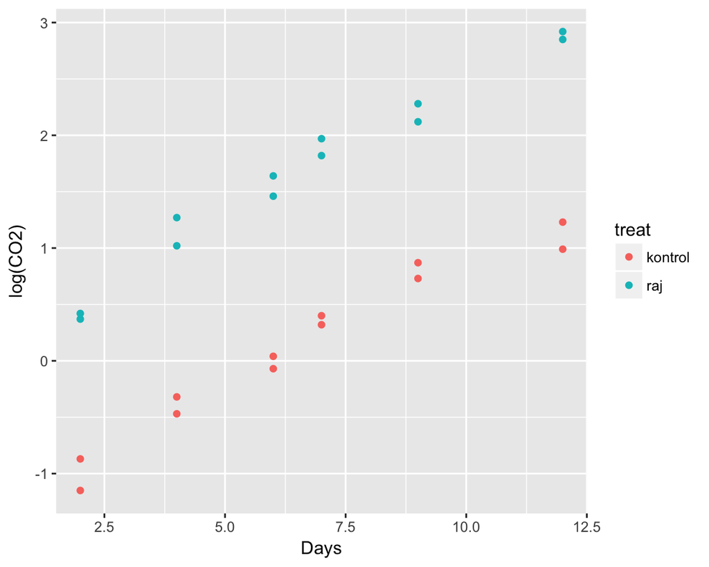

# 6.

Der lægges op til, at man inddrager et kvadratisk led til at beskrive sammenhængen mellem **day** og **logco2**.

En formelt test i R godkendes og kan udføres med følgende kode (-se evt. slides fra torsdag i kursusuge 2)

```r
mkvad <- lm(logco2 ~ treat + day + I(day^2), data = afl2)
anova(mkvad, m1)
```

```
Analysis of Variance Table

Model 1: logco2 ~ treat + day + I(day^2)
Model 2: logco2 ~ factor(day) + treat
  Res.Df     RSS Df Sum of Sq      F Pr(>F)
1     20 0.31511
2     17 0.26713  3   0.04798 1.0178 0.4093
```

Estimater fra modellen

```r
summary(mkvad)
```

```
Call:
lm(formula = logco2 ~ treat + day + I(day^2), data = afl2)

Residuals:
      Min        1Q    Median        3Q       Max
-0.237224 -0.071850 -0.001724  0.093809  0.186696

Coefficients:
             Estimate Std. Error t value Pr(>|t|)
(Intercept) -1.735397   0.113317  -15.31 1.64e-12 ***
treatraj     1.536667   0.051244   29.99  < 2e-16 ***
day          0.357843   0.035016   10.22 2.19e-09 ***
I(day^2)    -0.009247   0.002433   -3.80  0.00112 **
---
Signif. codes:  0 '***' 0.001 '**' 0.01 '*' 0.05 '.' 0.1 ' ' 1

Residual standard error: 0.1255 on 20 degrees of freedom
Multiple R-squared:  0.9887,    Adjusted R-squared:  0.987
F-statistic: 583.7 on 3 and 20 DF,  p-value: < 2.2e-16
```

Bemærk: modellen beskriver et 2. gradspolynomial hvor konstantleddet afhænger af, om vi betragter **treat=kontrol** eller **treat=raj**.